# DanielaGarciaChavero_PEC3_AC

[figure not shown]

## Universitat Oberta de Catalunya

### Aprendizaje computacional - PAC 3

Grado en Informática 2025-2  
Estudios de Informática, Multimedia y Telecomunicación

### PAC 3: Aprendizaje por refuerzo

### Consideraciones generales

- Esta PAC debe realizarse de forma **estrictamente individual**. Cualquier indicio de copia será penalizado con un suspenso (D) para todas las partes implicadas, lo que puede afectar también a la calificación final de la asignatura.
- Es necesario indicar **todas las fuentes** utilizadas en la realización de la PAC. En caso contrario, se considerará plagio, lo que será penalizado con un suspenso (D) y puede implicar una evaluación negativa de la asignatura.

### Formato de la entrega

- La actividad puede realizarse en **Jupyter Notebook** o en **Google Colab**.
- La entrega debe incluir obligatoriamente:
  - Dos archivos uno **formato HTML y el notebook**, donde se visualicen el código, los resultados y los comentarios.
- Dentro del archivo **.zip** se debe incluir:
  - El **notebook** utilizado.
  - Los **ficheros necesarios** para la correcta ejecución de la actividad (por ejemplo: datasets, imágenes, gráficos generados, etc.).
- La exportación a HTML puede realizarse con cualquier herramienta o comando que permita dicha exportación.
- Se recomienda verificar que el HTML se visualiza correctamente antes de realizar la entrega.

### Información de la práctica

Esta actividad se basa en el contenido del **Módulo didáctico 2. Agentes y sistemas multiagente** .

### Ponderación

| Ejercicio | Apartado | Puntos |
| --- | --- | --- |
| **Ejercicio 1** | a | 1 |
|  | b | 1 |
|  | c | 2 |
| **Ejercicio 2** | a | 1 |
|  | b | 1 |
|  | c | 2 |
|  | d | 1 |
| **Ejercicio 3** | a | 1 |
| Total |  | 10 |

### Fecha de entrega

**8 de junio de 2026**

**Nombre y apellidos:** Daniela García Chavero

## Índice de contenidos

Esta PEC está estructurada en tres bloques. Te recomendamos seguir el orden establecido, ya que ciertas secciones son dependientes y deben ejecutarse en orden para poder resolver los ejercicios posteriores.

- **Ejercicio 1 - Conceptos de agentes (4 pts.)**
- **Ejercicio 2 - Creación de agentes (5 pts.)**
- **Ejercicio 3 - Diseño de sistemas multiagente (1 pts.)**

# Agentes y aprendizaje por refuerzo

# Ejercicio 1 - Conceptos de agentes

**Ejercicio 1 [4 pts.]** En este primer ejercicio se les pide que se familiaricen con Gymnasium y con el entorno de aprendizaje. Con base en el contenido del curso, se debe responer a las preguntas.

**a) Conceptos [1 pt.]** Utiliza el entorno CartPole-v1 de Gymnasium.

- Identifica quién es el agente y quién es el entorno.
- Explica por qué este sistema cumple la definición de agente.

**a)**

**Identificación del agente y el entorno**

En este sistema, **el agente** es el **algoritmo o modelo computacional** encargado de decidir qué acción debe realizarse en cada momento. En **CartPole-v1**, las acciones posibles son **mover el carro hacia la izquierda** o **moverlo hacia la derecha**.

Por otro lado, **el entorno** es la **simulación física proporcionada por Gymnasium**. Este entorno incluye **el carro, el péndulo, la pista, la gravedad y las reglas físicas** que determinan cómo cambia el sistema después de cada acción del agente.

**¿Por qué este sistema cumple la definición de agente?**

Este sistema cumple la **definición de agente** porque el algoritmo **toma decisiones dentro de un entorno** con el objetivo de lograr una meta. Según la definición de **Wooldridge**, un agente es un **sistema computacional situado en un entorno**, capaz de **actuar de forma autónoma** para alcanzar **objetivos**.

El caso de **CartPole-v1** cumple esta definición porque el agente está **situado en un entorno**, ya que recibe información del estado de la simulación, como **la posición del carro, la velocidad del carro, el ángulo del péndulo y la velocidad angular del péndulo**. Además, actúa con **autonomía** porque selecciona acciones **sin intervención humana directa** durante la ejecución.

También tiene **orientación a objetivos**, ya que sus acciones buscan **mantener el péndulo en equilibrio** el mayor tiempo posible. Finalmente, muestra **reactividad** porque responde continuamente a los cambios del entorno ajustando el movimiento del carro según el **estado observado**.

Por lo tanto, **CartPole-v1** representa un ejemplo claro de **sistema agente-entorno**, ya que un **agente computacional** percibe el estado de una simulación, toma **decisiones autónomas** y actúa sobre el entorno para alcanzar un **objetivo definido**.

**b) Ejecuta un agente en Gymnasium y analiza su comportamiento. [1 pt.]**

A continuación, se presenta la inicialización del entorno CartPole-v1 utilizando la librería Gymnasium. Se implementa un fragmento de código en Python que permite interactuar con dicho entorno. Responde de manera justificada a las preguntas planteadas a continuación.

```python
import gymnasium as gym

env = gym.make("CartPole-v1")

obs, _ = env.reset()
for _ in range(10):
    action = env.action_space.sample()
    obs, reward, terminated, truncated, _ = env.step(action)
    if terminated or truncated:
        break
```

- ¿Qué devuelve la función reset()?
- ¿Qué información proporciona step(action)?
- ¿Qué significado tiene terminated vs truncated?
- ¿Cuántos episodios se están ejecutando?
- ¿Qué tipo de agente se utiliza en este problema y cuáles son las propiedades que lo caracterizan?

**b)**

**¿Qué devuelve la función reset()?**

La función **reset()** inicializa el entorno y lo coloca en su **estado inicial**. En Gymnasium, esta función devuelve una tupla con dos elementos: **obs** e **info**.

La variable **obs** representa la **observación inicial del entorno**. En el caso de **CartPole-v1**, esta observación es un vector numérico que contiene información sobre el estado del sistema: **la posición del carro, la velocidad del carro, el ángulo del péndulo y la velocidad angular del péndulo**.

El segundo valor, **info**, es un diccionario que puede contener **información adicional o de diagnóstico** sobre el entorno. En el código aparece como **_** porque no se utiliza directamente.

**¿Qué información proporciona step(action)?**

La función **step(action)** aplica una acción en el entorno y hace avanzar la simulación **un paso de tiempo**. En Gymnasium, devuelve cinco valores: **obs**, **reward**, **terminated**, **truncated** e **info**.

La nueva **obs** indica el **estado del entorno después de aplicar la acción**. La variable **reward** representa la recompensa obtenida en ese paso. En **CartPole-v1**, normalmente se recibe una recompensa de **+1 por cada paso** en el que el péndulo se mantiene en equilibrio.

El valor **terminated** indica si el episodio ha terminado por una **condición propia del entorno**, mientras que **truncated** indica si el episodio ha terminado por un **límite externo**, como alcanzar el número máximo de pasos. Finalmente, **info** proporciona información adicional del entorno.

**¿Qué significado tiene terminated frente a truncated?**

La variable **terminated** toma el valor **True** cuando el episodio termina por una **condición natural del problema**. En **CartPole-v1**, esto puede ocurrir si el péndulo se inclina demasiado o si el carro se desplaza fuera de los límites permitidos.

En cambio, **truncated** toma el valor **True** cuando el episodio se interrumpe por una **restricción externa**, aunque el agente no haya fallado necesariamente. Por ejemplo, en **CartPole-v1** puede ocurrir cuando se alcanza el **límite máximo de pasos del episodio**.

De manera que, **terminated** indica un final provocado por el estado del entorno, mientras que **truncated** indica un final provocado por una limitación externa de la simulación.

**¿Cuántos episodios se están ejecutando?**

En este código se está ejecutando **un solo episodio**. Esto se debe a que la función **env.reset()** se llama una única vez antes del bucle **for**.

El bucle ejecuta como máximo **10 pasos dentro del mismo episodio**. Si durante esos pasos **terminated** o **truncated** toman el valor **True**, el bucle se detiene con **break**. Sin embargo, como no se vuelve a llamar a **env.reset()**, no se inicia un nuevo episodio.

**¿Qué tipo de agente se utiliza en este problema y cuáles son sus propiedades?**

En este código se utiliza un **agente aleatorio**. Esto se observa en la instrucción **action = env.action_space.sample()**, que selecciona una acción al azar del espacio de acciones disponible.

Este agente tiene varias propiedades importantes. En primer lugar, es un agente **estocástico**, porque sus acciones dependen del azar y no de una regla fija. Además, es un agente **no entrenado**, ya que no ha aprendido una política para resolver el problema.

También es un agente que **no utiliza la observación del entorno** para decidir. Aunque el código recibe la variable **obs**, el agente no la analiza para elegir si debe mover el carro hacia la izquierda o hacia la derecha. Por esta razón, no se puede considerar un agente reactivo inteligente, ya que no adapta sus acciones al estado observado.

Además, este agente **no aprende de la recompensa**, porque no usa el valor de **reward** para mejorar su comportamiento en pasos futuros. Su comportamiento consiste simplemente en ejecutar acciones aleatorias, sin intentar optimizar de manera racional el objetivo de **mantener el péndulo en equilibrio**.

Por lo tanto, el agente utilizado en este fragmento es un **agente aleatorio, autónomo, estocástico, no entrenado y sin aprendizaje**, que interactúa con el entorno pero no toma decisiones inteligentes basadas en el estado ni en la recompensa recibida.

**c) Comportamiento de un agente [2 pt.]**

¿Cómo implementarías una versión más completa y correcta del programa? Incorpora una estructura que refleje mejor el comportamiento de un agente inteligente. En tu respuesta, desarrolla una solución que incluya y justique cada uno de los siguientes puntos:

- Manejo explícito de episodios
- Control claro de finalización del episodio
- Acumulación de recompensas
- Cierre adecuado del entorno
- (Opcional) Incorporación de renderizado

**c) Justificación de la implementación general del agente mejorado**

Antes de ejecutar el programa, se comprueba que estén disponibles las librerías necesarias, principalmente **gymnasium** y **matplotlib**. La librería **Gymnasium** permite crear e interactuar con el entorno **CartPole-v1**, mientras que **matplotlib** se utiliza para mostrar el renderizado de forma segura dentro del cuaderno.

La implementación sigue la estructura habitual de un problema de **aprendizaje por refuerzo**: el agente observa el estado del entorno, ejecuta una acción, recibe una recompensa y continúa hasta que el episodio termina. En este caso, el objetivo es mantener el péndulo en equilibrio durante el mayor tiempo posible.

**1. Manejo explícito de episodios**

Como **CartPole-v1** es un entorno episódico, cada ejecución tiene un inicio y un final definidos. Por ello, se utiliza un bucle externo que permite repetir la simulación durante varios episodios.

Al inicio de cada episodio se llama a **env.reset()**, lo que reinicia el entorno y sitúa al agente en un nuevo estado inicial. Esto permite analizar el comportamiento del agente en distintos intentos y comparar la recompensa obtenida en cada uno.

**2. Control de finalización del episodio**

Después de cada acción se comprueban las variables **terminated** y **truncated**. La primera indica que el episodio ha terminado por una condición propia del entorno, como la caída del péndulo o la salida del carro de los límites permitidos.

La variable **truncated**, en cambio, señala que el episodio se ha detenido por una condición externa, como alcanzar el número máximo de pasos. Por este motivo, la condición **if terminated or truncated:** permite finalizar correctamente cada episodio y evita que el agente siga actuando cuando la simulación ya no es válida.

**3. Acumulación de recompensas**

Para medir el rendimiento del agente, se utiliza la variable **episode_reward**. Esta se inicializa a cero al comienzo de cada episodio y se actualiza en cada paso con **episode_reward += reward**.

En **CartPole-v1**, el agente recibe recompensa mientras consigue mantener el péndulo en equilibrio. Por tanto, una recompensa acumulada más alta indica que el agente ha logrado sostener el sistema durante más tiempo. Esta métrica permite comparar fácilmente los resultados entre episodios.

**4. Cierre adecuado del entorno**

Al terminar la ejecución se utiliza **env.close()** para cerrar correctamente el entorno. Esta instrucción libera los recursos utilizados por **Gymnasium** y ayuda a evitar procesos activos en segundo plano.

Esto es especialmente importante en entornos como **Jupyter Notebook**, donde una mala gestión del renderizado puede dejar procesos bloqueados o ventanas gráficas abiertas. Por tanto, incluir el cierre del entorno mejora la estabilidad de la ejecución.

**5. Renderizado opcional**

El renderizado se incluye como evidencia visual del comportamiento del agente. En esta implementación se utiliza **render_mode="rgb_array"** en lugar de **"human"**, ya que este modo evita abrir ventanas externas que pueden bloquear el cuaderno.

Con **rgb_array**, el entorno genera una imagen del estado de la simulación, que posteriormente se muestra mediante **matplotlib**. Aunque no se obtiene una animación en tiempo real, sí se conserva el fotograma final de cada episodio como prueba visual.

Esta opción resulta adecuada para el entregable, ya que permite exportar el cuaderno a **HTML** manteniendo incrustada la evidencia gráfica del resultado. (Consultada con el profesorado)

### Realiza una implementación mejorada en la siguiente sección.

```
Episodio 1 finalizado. Recompensa acumulada: 15.0
```

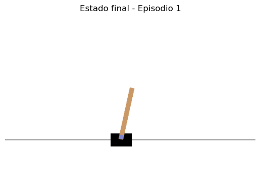

```
Episodio 2 finalizado. Recompensa acumulada: 12.0
```

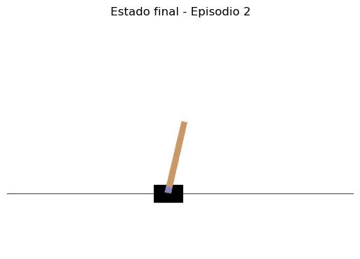

```
Episodio 3 finalizado. Recompensa acumulada: 19.0
```

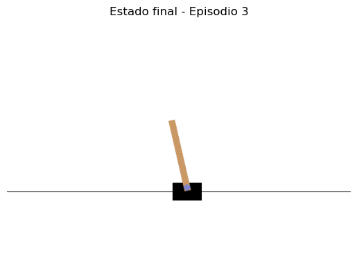

```
Episodio 4 finalizado. Recompensa acumulada: 31.0
```

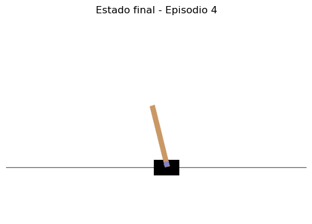

```
Episodio 5 finalizado. Recompensa acumulada: 15.0
```

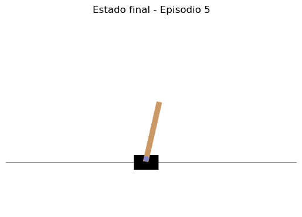

```python
import gymnasium as gym
import matplotlib.pyplot as plt

# 5. Incorporación de renderizado, se utiliza 'rgb_array' para evitar bloqueos y mostrar evidencia del resultado via html.
env = gym.make("CartPole-v1", render_mode="rgb_array")

num_episodes = 5

# 1. Manejo explícito de episodios
for episode in range(num_episodes):
    # Se reinicia el entorno al inicio de cada episodio
    obs, info = env.reset()

    # 3. Acumulación de recompensas (inicialización)
    episode_reward = 0

    # Bucle interno, el cual se ejecuta hasta que el episodio termina
    while True:
        # Selección de acción (aleatoria como base estructural)
        action = env.action_space.sample()

        # Interacción con el entorno
        obs, reward, terminated, truncated, info = env.step(action)

        # 3. Acumulación de recompensas (actualización)
        episode_reward += reward

        # 2. Control claro de finalización del episodio
        if terminated or truncated:
            print(f"Episodio {episode + 1} finalizado. Recompensa acumulada: {episode_reward}")

            # Renderizado de un fotograma estático al finalizar el episodio
            plt.imshow(env.render())
            plt.axis('off')
            plt.title(f"Estado final - Episodio {episode + 1}")
            plt.show()
            break

# 4. Cierre adecuado del entorno
env.close()
```

# Ejercicio 2 - Creación de agentes

**Ejercicio 2 [5 pts.]**

## 🐶 NAVEGACIÓN DE UN CACHORRO EN UN LABERINTO CON OBSTÁCULOS

En una tabla existe un elemento denominado **cachorro**, el cual ocupa varias casillas y tiene una forma específica.  
El cachorro está compuesto por **cuatro extremidades (E)**, un **cuerpo (C)** y una **cabeza (H)**, distribuidos dentro de esas casillas.

### Movimiento del cachorro

El agente puede mover todas sus partes simultáneamente como una sola unidad, desplazándose en conjunto hacia arriba, abajo, izquierda o derecha, **respetando siempre la forma definida de su cuerpo y los límites del entorno**.

```
# Acciones del agente
ACTIONS = {
    0: ("ARRIBA", (-1, 0)),
    1: ("ABAJO", (1, 0)),
    2: ("IZQUIERDA", (0, -1)),
    3: ("DERECHA", (0, 1))
}

# Forma del perro (cuerpo del agente)
DOG_SHAPE = [
    (-1, -1), (-1, 0),
    (0, 0), (0, 1),
    (1, -1), (1, 0)
]
```

### Laberinto y obstáculos

Dentro del laberinto existen múltiples obstáculos, marcados con la letra **“X”**, los cuales representan áreas por las que el cachorro **no puede desplazarse**.

### Objetivo del problema

El objetivo es que el cachorro pueda recorrer el laberinto de manera eficiente, **evitando chocar con los obstáculos 🚧**.

### Inicio y fin

El cachorro debe desplazarse desde el **punto inicial (cuerpo)** hasta el **punto final (casa)**, eludiendo todos los obstáculos del laberinto.

### Requerimiento

Se solicita desarrollar las siguientes actividades **para los agentes de aprendizaje por refuerzo**:

- Completar el código del agente basado en recompensas (enfoque simple).
- Analizar el funcionamiento del agente basado en el algoritmo **Q-learning**.

```python
# =========================
# NO MODIFICAR ESTA CELDA
# =========================
import random
import time
import matplotlib.pyplot as plt
import numpy as np
ACTIONS =  {
    0: ("ARRIBA", (-1, 0)),
    1: ("ABAJO", (1, 0)),
    2: ("IZQUIERDA", (0, -1)),
    3: ("DERECHA", (0, 1))
}

DOG_SHAPE = [
    (-1, -1), (-1, 0),
    (0, 0), (0, 1),
    (1, -1), (1, 0)
]

def es_valido(lab, fila, col):
    filas, cols = len(lab), len(lab[0])

    for df, dc in DOG_SHAPE:
        r, c = fila + df, col + dc
        if r < 0 or r >= filas or c < 0 or c >= cols:
            return False
        if lab[r][c] == 'X':
            return False

    return True

def mostrar_tablero(laberinto, estado, paso=None, accion=None, recompensa=None):
    filas, cols = len(laberinto), len(laberinto[0])
    vista = [fila[:] for fila in laberinto]

    partes = {
        (-1, -1): 'E', (-1, 0): 'E',
        (0, 0): 'C',  (0, 1): 'H',
        (1, -1): 'E', (1, 0): 'E'
    }

    f, c = estado
    for (df, dc), simb in partes.items():
        vista[f + df][c + dc] = simb

    if paso is not None:
        print(f"\nPaso: {paso}")
    if accion:
        print(f"Acción: {accion}")
    if recompensa is not None:
        print(f"Recompensa: {recompensa}")

    for fila in vista:
        print(" ".join(fila))
    print("-" * (cols * 2))

def render_matplotlib(laberinto, estado):
    filas, cols = len(laberinto), len(laberinto[0])
    grid = np.zeros((filas, cols, 3))

    # Obstáculos
    for r in range(filas):
        for c in range(cols):
            if laberinto[r][c] == 'X':
                grid[r, c] = [1, 1, 1]  # blanco
    # Obstáculos
    for r in range(filas):
        for c in range(cols):
            if laberinto[r][c] == 'O':
                grid[r, c] = [1, 0, 1]  # magenta
    # Perrito
    partes = {
        (-1, -1): [0.2, 0.6, 1],   # E
        (-1, 0):  [0.2, 0.6, 1],
        (0, 0):   [0, 1, 0],       # C
        (0, 1):   [1, 0, 0],       # H
        (1, -1):  [0.2, 0.6, 1],
        (1, 0):   [0.2, 0.6, 1],
    }

    f, c = estado
    for (df, dc), color in partes.items():
        grid[f + df, c + dc] = color

    plt.imshow(grid)
    plt.xticks([])
    plt.yticks([])
    plt.show(block=False)
    plt.pause(0.2)
    plt.clf()
```

**a) Construcción del agente [1 pt.]**

Completa el siguiente código para un agente que aprende basado en recompensas simples. Debes reemplazar los espacios en blanco (___) con el valor o instrucción correcta. Tu solución debe completar los fragmentos de código que no están desarrollados.

**Recuerda:** no debes modificar las celdas donde aparece la leyenda # NO MODIFICAR ESTA CELDA, ni tampoco las celdas con # ¡NO MODIFICAR ESTA FUNCIÓN!.

```python
class DogMazeEnv:
    # ¡NO MODIFICAR ESTA FUNCIÓN!
    def __init__(self, laberinto, inicio, fin):
        self.laberinto = laberinto
        self.inicio = inicio
        self.fin = fin
        self.estado = inicio
        self.done = False
        self.filas = len(laberinto)
        self.cols = len(laberinto[0])
        self.action_space = len(ACTIONS)
        self.observation_space = (self.filas, self.cols)

    # ¡NO MODIFICAR ESTA FUNCIÓN!
    def reset(self):
        self.estado = self.inicio
        self.done = False
        return self.estado

    # ¡NO MODIFICAR ESTA FUNCIÓN!
    def calcular_nueva_posicion(self, action):
      # Obtener la acción seleccionada y su desplazamiento (fila, columna)
      accion, (df, dc) = ACTIONS[action]

      # Mostrar por pantalla la acción elegida y el movimiento asociado
      print(f"Acción seleccionada: {accion}")

      # Calcular la nueva posición sumando el desplazamiento al estado actual
      nf = self.estado[0] + df
      nc = self.estado[1] + dc

      # Crear el nuevo estado del agente con la nueva posición
      nuevo_estado = (nf, nc)

      return nuevo_estado, nf, nc

    # ¡NO MODIFICAR ESTA FUNCIÓN!
    def render(self):
        mostrar_tablero(self.laberinto, self.estado)
        render_matplotlib(self.laberinto, self.estado)
        time.sleep(0.3)

    # AGREGA TUS CAMBIOS
    def step(self, action):
        # ! NO MODIFICAR
        if self.done:
            raise Exception("El episodio ya terminó. Llama a reset().")

        # CALCULAR NUEVO ESTADO
        nuevo_estado, nf, nc = self.calcular_nueva_posicion(action)

        # MOVIMIENTO INVÁLIDO
        if not es_valido(self.laberinto, nf, nc):
            recompensa = -10
            return self.estado, recompensa, self.done, {"accion": ACTIONS[action][0]}

        # MOVIMIENTO VÁLIDO
        self.estado = nuevo_estado
        recompensa = -1

        # OBJETIVO ALCANZADO
        if self.estado == self.fin:
            recompensa = 100
            self.done = True

        # RETORNO OBLIGATORIO
        return self.estado, recompensa, self.done, {"accion": ACTIONS[action][0]}
```

```
Estado Inicial: (4, 1)
Acciones disponibles del agente:
0: ARRIBA
1: ABAJO
2: IZQUIERDA
3: DERECHA
. . . . . . . . . .
. . . . . . X . . .
. . . . . . . . . .
E E . . . . . . . X
. C H . X . . . . .
E E . . . . . . . .
. . . . . . . . . .
. . . . . . . O . .
. . . X . . . . . X
--------------------
```

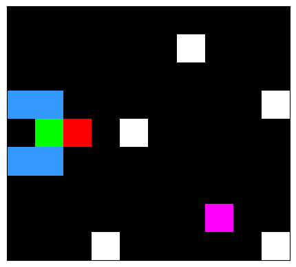

```python
# =========================
# NO MODIFICAR ESTA CELDA
# =========================
laberinto = [
    ['.', '.', '.', '.', '.', '.', '.', '.', '.', '.'],
    ['.', '.', '.', '.', '.', '.', 'X', '.', '.', '.'],
    ['.', '.', '.', '.', '.', '.', '.', '.', '.', '.'],
    ['.', '.', '.', '.', '.', '.', '.', '.', '.', 'X'],
    ['.', '.', '.', '.', 'X', '.', '.', '.', '.', '.'],
    ['.', '.', '.', '.', '.', '.', '.', '.', '.', '.'],
    ['.', '.', '.', '.', '.', '.', '.', '.', '.', '.'],
    ['.', '.', '.', '.', '.', '.', '.', 'O', '.', '.'],
    ['.', '.', '.', 'X', '.', '.', '.', '.', '.', 'X']
]
inicio = (4, 1)  # posición inicial del cuerpo
fin = (7, 7)     # posición objetivo
env = DogMazeEnv(laberinto, inicio, fin)
print(f"Estado Inicial: {env.estado}")
print("Acciones disponibles del agente:")
for clave, (nombre, movimiento) in ACTIONS.items():
    print(f"{clave}: {nombre}")
env.render()
```

```
Acción seleccionada: ARRIBA
Acción seleccionada: ABAJO
Acción seleccionada: ARRIBA
Acción seleccionada: IZQUIERDA
Acción seleccionada: ABAJO
Acción seleccionada: IZQUIERDA
Acción seleccionada: ARRIBA
Acción seleccionada: ABAJO
Acción seleccionada: ABAJO
Acción seleccionada: ARRIBA
Acción seleccionada: IZQUIERDA
Acción seleccionada: DERECHA
Acción seleccionada: ABAJO
Acción seleccionada: DERECHA
Acción seleccionada: DERECHA
Acción seleccionada: ARRIBA
Acción seleccionada: ARRIBA
Acción seleccionada: ABAJO
Acción seleccionada: DERECHA
Acción seleccionada: ARRIBA
Acción seleccionada: ABAJO
Acción seleccionada: DERECHA
Acción seleccionada: ARRIBA
Acción seleccionada: DERECHA
Acción seleccionada: ABAJO
Acción seleccionada: DERECHA
. . . . . . . . . .
. . . . . . X . . .
. . . . . . . . . .
. . . . . . . . . X
. . . . X . . . . .
. . . . . . . . . .
. . . . . . E E . .
. . . . . . . C H .
. . . X . . E E . X
--------------------
```

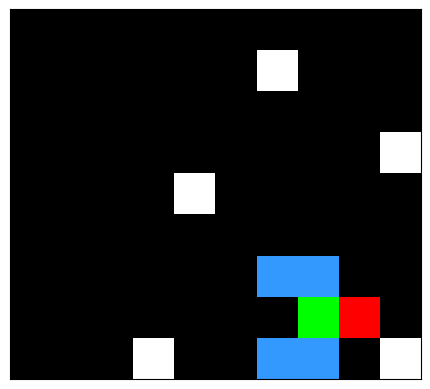

```
🎯 Meta alcanzada
```

```python
# REINICIAR ENTORNO
estado = env.reset()
done = False
max_iteraciones = 1000
iteracion = 0

umbral = int(max_iteraciones * 0.1)     # 10% → 100
intervalo = int(max_iteraciones / 10)   # → 100 (10 veces en total)

# SIMULACIÓN DEL AGENTE
while not done and iteracion < max_iteraciones:

    # SELECCIÓN DE ACCIÓN ALEATORIA
    accion = random.randint(0, env.action_space - 1)

    # INTERACCIÓN CON EL ENTORNO
    estado, recompensa, done, info = env.step(accion)

    # Render solo después del 10% y máximo 10 veces
    if iteracion >= umbral and iteracion % intervalo == 0:
        env.render()

    # RENDER FINAL SI TERMINA
    if done:
        env.render()

    iteracion += 1

# MENSAJE FINAL
if not done:
    print("⚠️ El agente no llegó a la meta en el número máximo de iteraciones")
else:
    print("🎯 Meta alcanzada")
```

**b) Entorno del agente [1 pt.]**

- ¿Cuál sería el resultado de tu agente si utiliza, en lugar del mapa actual, el laberinto B(laberinto_b)?
- ¿Por qué se puede decir que un mal laberinto provoca un aprendizaje fallido en un agente?
- ¿Qué acciones podrías tomar para corregir un laberinto que no tiene solución?

```
Estado Inicial: (4, 1)
Acciones disponibles del agente:
0: ARRIBA
1: ABAJO
2: IZQUIERDA
3: DERECHA
. . . . . . . . . .
. . . . . . X . . .
. . . . . . . . . .
E E . . . . . . . X
. C H . X . . . . .
E E . . . . . . . .
. . . . . . . . . .
. . . . . . X O . .
. . . X . . . . . X
--------------------
```

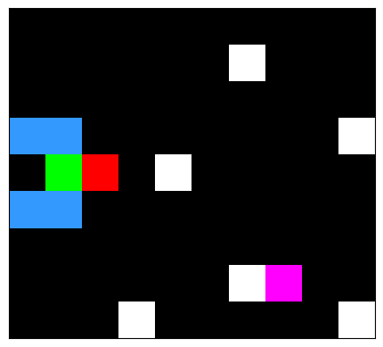

```python
# =========================
# NO MODIFICAR ESTA CELDA
# =========================
laberinto_b = [
    ['.', '.', '.', '.', '.', '.', '.', '.', '.', '.'],
    ['.', '.', '.', '.', '.', '.', 'X', '.', '.', '.'],
    ['.', '.', '.', '.', '.', '.', '.', '.', '.', '.'],
    ['.', '.', '.', '.', '.', '.', '.', '.', '.', 'X'],
    ['.', '.', '.', '.', 'X', '.', '.', '.', '.', '.'],
    ['.', '.', '.', '.', '.', '.', '.', '.', '.', '.'],
    ['.', '.', '.', '.', '.', '.', '.', '.', '.', '.'],
    ['.', '.', '.', '.', '.', '.', 'X', 'O', '.', '.'],
    ['.', '.', '.', 'X', '.', '.', '.', '.', '.', 'X']
]
inicio = (4, 1)  # posición inicial del cuerpo
fin = (7, 7)     # posición objetivo
env_b = DogMazeEnv(laberinto_b, inicio, fin)
print(f"Estado Inicial: {env_b.estado}")
print("Acciones disponibles del agente:")
for clave, (nombre, movimiento) in ACTIONS.items():
    print(f"{clave}: {nombre}")
env_b.render()
```

[output not shown]

[output cut: 56 more lines]

```
Acción seleccionada: ARRIBA
Acción seleccionada: ABAJO
Acción seleccionada: DERECHA
Acción seleccionada: IZQUIERDA
Acción seleccionada: ABAJO
. . . . . . . . . .
. . . . . . X . . .
. . . . . . . . . .
. . . . . . . . . X
. . . . X . . . . .
. . E E . . . . . .
. . . C H . . . . .
. . E E . . X O . .
. . . X . . . . . X
--------------------
```

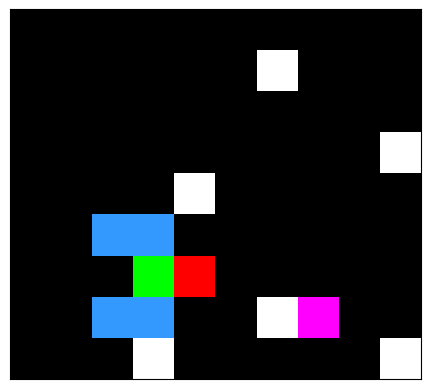

[output not shown]

[output cut: 55 more lines]

```
Acción seleccionada: DERECHA
Acción seleccionada: IZQUIERDA
Acción seleccionada: ABAJO
Acción seleccionada: DERECHA
Acción seleccionada: DERECHA
. . . . . . . . . .
. . . . . . X . . .
. . . . . . . . . .
. . . . . . . . . X
. . . . X . . . . .
. . . . . . . . . .
. E E . . . . . . .
. . C H . . X O . .
. E E X . . . . . X
--------------------
```

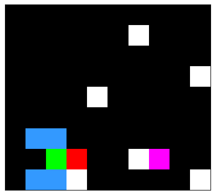

[output not shown]

[output cut: 55 more lines]

```
Acción seleccionada: ARRIBA
Acción seleccionada: IZQUIERDA
Acción seleccionada: ARRIBA
Acción seleccionada: DERECHA
Acción seleccionada: ARRIBA
. . . . . . . . . .
. E E . . . X . . .
. . C H . . . . . .
. E E . . . . . . X
. . . . X . . . . .
. . . . . . . . . .
. . . . . . . . . .
. . . . . . X O . .
. . . X . . . . . X
--------------------
```

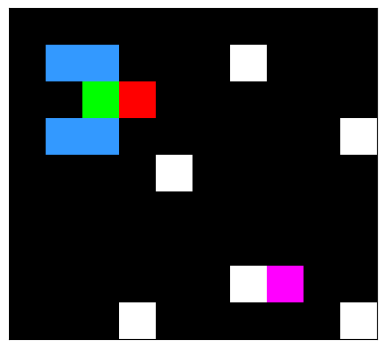

[output not shown]

[output cut: 55 more lines]

```
Acción seleccionada: ARRIBA
Acción seleccionada: ABAJO
Acción seleccionada: DERECHA
Acción seleccionada: DERECHA
Acción seleccionada: IZQUIERDA
. . . . . . . . . .
. . . . . . X . . .
. . . . . . . . . .
. . . . . . . . . X
. . . . X . . . . .
. . . E E . . . . .
. . . . C H . . . .
. . . E E . X O . .
. . . X . . . . . X
--------------------
```

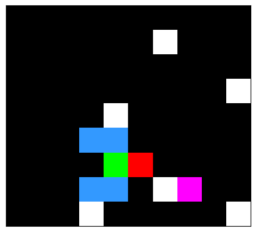

[output not shown]

[output cut: 55 more lines]

```
Acción seleccionada: IZQUIERDA
Acción seleccionada: ARRIBA
Acción seleccionada: IZQUIERDA
Acción seleccionada: IZQUIERDA
Acción seleccionada: DERECHA
. . . . . . . . . .
. . . . . . X . . .
. . . . . . . . . .
. . . . . . . . . X
. E E . X . . . . .
. . C H . . . . . .
. E E . . . . . . .
. . . . . . X O . .
. . . X . . . . . X
--------------------
```

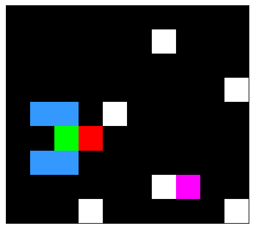

[output not shown]

[output cut: 55 more lines]

```
Acción seleccionada: IZQUIERDA
Acción seleccionada: DERECHA
Acción seleccionada: ABAJO
Acción seleccionada: ARRIBA
Acción seleccionada: ABAJO
. . . . . . . . . .
. . . . . . X . . .
. E E . . . . . . .
. . C H . . . . . X
. E E . X . . . . .
. . . . . . . . . .
. . . . . . . . . .
. . . . . . X O . .
. . . X . . . . . X
--------------------
```

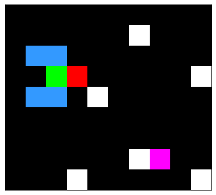

[output not shown]

[output cut: 55 more lines]

```
Acción seleccionada: IZQUIERDA
Acción seleccionada: DERECHA
Acción seleccionada: ABAJO
Acción seleccionada: ARRIBA
Acción seleccionada: IZQUIERDA
. . . . . . . . . .
. . . . . . X . . .
. . . . . . . . . .
. . . . . . . . . X
. . . . X . . . . .
E E . . . . . . . .
. C H . . . . . . .
E E . . . . X O . .
. . . X . . . . . X
--------------------
```

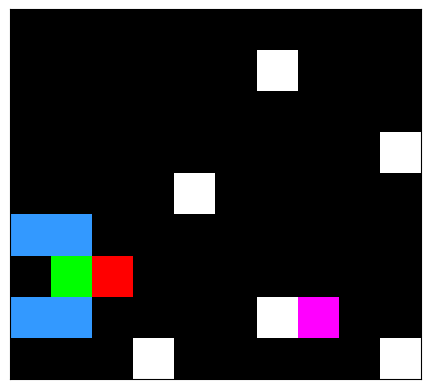

[output not shown]

[output cut: 55 more lines]

```
Acción seleccionada: ABAJO
Acción seleccionada: DERECHA
Acción seleccionada: ABAJO
Acción seleccionada: IZQUIERDA
Acción seleccionada: IZQUIERDA
. . . . . . . . . .
. . . . . . X . . .
. . . . . . . . . .
. . . . . . . . . X
. . . . X . . . . .
. E E . . . . . . .
. . C H . . . . . .
. E E . . . X O . .
. . . X . . . . . X
--------------------
```

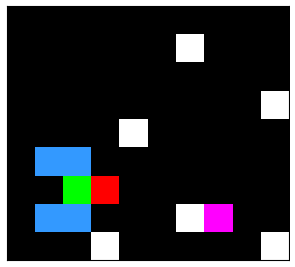

[output not shown]

[output cut: 55 more lines]

```
Acción seleccionada: ABAJO
Acción seleccionada: ARRIBA
Acción seleccionada: ABAJO
Acción seleccionada: ABAJO
Acción seleccionada: IZQUIERDA
. . . . . . . . . .
. . . . . . X . . .
. . . . . . . . . .
. . . . . . . . . X
. . . . X . . . . .
. . . . . . . . . .
E E . . . . . . . .
. C H . . . X O . .
E E . X . . . . . X
--------------------
```

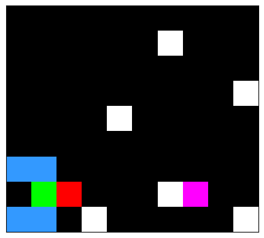

[output not shown]

[output cut: 45 more lines]

```
Acción seleccionada: IZQUIERDA
Acción seleccionada: ARRIBA
Acción seleccionada: IZQUIERDA
Acción seleccionada: DERECHA
Acción seleccionada: ABAJO
Acción seleccionada: ABAJO
Acción seleccionada: IZQUIERDA
Acción seleccionada: IZQUIERDA
Acción seleccionada: IZQUIERDA
Acción seleccionada: ARRIBA
Acción seleccionada: ARRIBA
Acción seleccionada: ABAJO
Acción seleccionada: IZQUIERDA
Acción seleccionada: IZQUIERDA
⚠️ El agente no llegó a la meta en el número máximo de iteraciones
```

```python
# REINICIAR ENTORNO
estado = env_b.reset()
done = False
max_iteraciones = 1000
iteracion = 0

umbral = int(max_iteraciones * 0.1)     # 10% → 100
intervalo = int(max_iteraciones / 10)   # → 100 (10 veces en total)

# SIMULACIÓN DEL AGENTE
while not done and iteracion < max_iteraciones:

    # SELECCIÓN DE ACCIÓN ALEATORIA
    accion = random.randint(0, env_b.action_space - 1)

    # INTERACCIÓN CON EL ENTORNO
    estado, recompensa, done, info = env_b.step(accion)

    # Render solo después del 10% y máximo 10 veces
    if iteracion >= umbral and iteracion % intervalo == 0:
        env_b.render()

    # RENDER FINAL SI TERMINA
    if done:
        env_b.render()

    iteracion += 1

# MENSAJE FINAL
if not done:
    print("⚠️ El agente no llegó a la meta en el número máximo de iteraciones")
else:
    print("🎯 Meta alcanzada")
```

**b) Entorno del agente [1 pt.]**

**¿Cuál sería el resultado de tu agente si utiliza el laberinto B (laberinto_b)?**

Si el agente utiliza **laberinto_b**, lo más probable es que no consiga llegar a la meta dentro del número máximo de iteraciones. En ese caso, el programa finalizaría mostrando **⚠️ El agente no llegó a la meta en el número máximo de iteraciones**

Aunque la casilla objetivo **O** se encuentre en la posición **(7, 7)**, el cachorro ocupa más de una casilla dentro del laberinto. Por lo tanto, no basta con que la posición de la meta esté libre, ya que también deben estar libres las casillas necesarias para colocar correctamente el cuerpo, la cabeza y las extremidades del cachorro durante el recorrido.

**¿Por qué se puede decir que un mal laberinto provoca un aprendizaje fallido en un agente?**

Un laberinto mal diseñado puede provocar un aprendizaje fallido porque el agente no tiene ninguna forma real de alcanzar la meta. Si el entorno no ofrece una solución posible, el agente nunca recibe la recompensa positiva asociada al éxito.

En ese caso, aunque se utilice una estrategia de aprendizaje como **Q-learning**, el agente solo acumulará penalizaciones, movimientos inválidos o recorridos sin salida. De manera que el problema no estaría en el algoritmo, sino en el diseño del entorno.

Dicho de otra forma, un agente no puede aprender una política exitosa si el laberinto no contiene al menos un camino válido entre el punto de inicio y la meta.

**¿Qué acciones podrías tomar para corregir un laberinto que no tiene solución?**

Para corregir un laberinto sin solución, se deberían revisar los obstáculos y comprobar que el agente completo puede desplazarse por el mapa, no solo una parte de él.

Algunas acciones posibles serían eliminar o mover los obstáculos que bloquean el paso, cambiar la posición de la meta a una zona alcanzable o modificar la posición inicial si el agente empieza en un área encerrada. También sería recomendable verificar el laberinto antes del entrenamiento mediante una búsqueda como **BFS** o **DFS**, para confirmar que existe al menos una ruta válida.

En resumen, el laberinto debe rediseñarse teniendo en cuenta el tamaño completo del cachorro y no únicamente la casilla central que representa su posición. Solo así se puede garantizar que el entorno permite un aprendizaje correcto.

**c) Agente basado en Q-learing[2 pt.]**

Analiza el siguiente fragmento de código y los resultados obtenidos tras ejecutar esta celda, correspondiente a un agente que aprende basado en Q-learning.

Luego responde a las preguntas de la actividad: Explica el funcionamiento del algoritmo Q-learning.

- ¿Qué representa q_table?
- ¿Qué pasa si el estado no existe en q_table?
- ¿Por qué se inicializa con ceros?
- ¿Qué significa random.random() < epsilon?
- ¿Qué significan las épocas en este ejercicio?
- ¿En qué época sería correcto terminar el aprendizaje de este modelo?
- ¿Puedes graficar cuáles serían las dos mejores políticas(pasos) para llegar al objetivo?

**Recuerda:** no debes modificar las celdas donde aparece la leyenda # NO MODIFICAR ESTA CELDA, ni tampoco las celdas con # ¡NO MODIFICAR ESTA FUNCIÓN!.

```python
# =========================
# NO MODIFICAR ESTA CELDA
# =========================
import numpy as np
import matplotlib.pyplot as plt

def graficar_resultados(rewards_history, length_history, agent, config):
    """
    Grafica los resultados del entrenamiento de Q-learning.

    Parámetros:
    - rewards_history: lista de recompensas por episodio
    - length_history: lista de número de pasos por episodio
    - agent: agente entrenado (debe contener agent.errors)
    - config: diccionario de configuración (usa rolling_window)
    """

    w = config["rolling_window"]

    def smooth(data):
        if len(data) < w:
            return data  # evitar errores si hay pocos datos
        return np.convolve(data, np.ones(w) / w, mode="valid")

    plt.figure(figsize=(12, 4))

    # =========================
    # Recompensas
    # =========================
    plt.subplot(1, 3, 1)
    plt.title("Recompensas")
    plt.xlabel("Episodios")
    plt.ylabel("Recompensa")
    plt.plot(smooth(rewards_history))
    plt.grid(True, linestyle="--", alpha=0.5)

    # =========================
    # Longitud de episodios
    # =========================
    plt.subplot(1, 3, 2)
    plt.title("Longitud de episodios")
    plt.xlabel("Episodios")
    plt.ylabel("Número de pasos")
    plt.plot(smooth(length_history))
    plt.grid(True, linestyle="--", alpha=0.5)

    # =========================
    # Error de entrenamiento
    # =========================
    plt.subplot(1, 3, 3)
    plt.title("Error de entrenamiento (TD Error)")
    plt.xlabel("Iteraciones")
    plt.ylabel("Error")
    plt.plot(smooth(agent.errors))
    plt.grid(True, linestyle="--", alpha=0.5)

    plt.tight_layout()
    plt.show()
```

```python
# =========================
# NO MODIFICAR ESTA CELDA
# =========================
CONFIG = {
    "episodes": 500,
    "learning_rate": 0.1,
    "gamma": 0.95,
    "epsilon": 1.0,
    "epsilon_decay": 0.99,
    "rolling_window": 50
}
```

```python
# =========================
# NO MODIFICAR ESTA CELDA
# =========================
# =========================
# AGENTE Q-LEARNING
# =========================
class QAgent:
    def __init__(self, actions, cfg):
        self.actions = actions
        self.lr = cfg["learning_rate"]
        self.gamma = cfg["gamma"]
        self.epsilon = cfg["epsilon"]
        self.epsilon_decay = cfg["epsilon_decay"]

        self.q_table = {}
        self.errors = []

    def get_q(self, state):
        if state not in self.q_table:
            self.q_table[state] = np.zeros(len(self.actions))
        return self.q_table[state]

    def choose_action(self, state):
        if random.random() < self.epsilon:
            return random.randint(0, len(self.actions) - 1)
        return int(np.argmax(self.get_q(state)))

    def learn(self, state, action, reward, next_state, done):
        q = self.get_q(state)

        target = reward
        if not done:
            target += self.gamma * np.max(self.get_q(next_state))

        error = target - q[action]
        q[action] += self.lr * error

        self.errors.append(abs(error))

        self.epsilon *= self.epsilon_decay


env = DogMazeEnv(laberinto, inicio, fin)
state = env.reset()
done = False
agent = QAgent(ACTIONS, CONFIG)
def entrenar_agente(env, agent, config):
    """
    Ejecuta el entrenamiento del agente en el entorno dado.

    Parámetros:
    - env: entorno (DogMazeEnv)
    - agent: agente (QAgent)
    - config: diccionario de configuración

    Retorna:
    - rewards_history: lista de recompensas por episodio
    - length_history: lista de pasos por episodio
    """

    rewards_history = []
    length_history = []

    for ep in range(config["episodes"]):
        state = env.reset()
        done = False

        total_reward = 0
        steps = 0

        while not done:
            action = agent.choose_action(state)
            next_state, reward, done, _ = env.step(action)

            agent.learn(state, action, reward, next_state, done)

            state = next_state
            total_reward += reward
            steps += 1

        rewards_history.append(total_reward)
        length_history.append(steps)

        # Decaimiento de epsilon
        agent.epsilon = max(agent.epsilon * config["epsilon_decay"], 0.01)

        print(f"Episodio {ep+1} | Recompensa: {total_reward:.1f} | Epsilon: {agent.epsilon:.3f}")

    print("\n🎯 Entrenamiento terminado")

    return rewards_history, length_history

env = DogMazeEnv(laberinto, inicio, fin)
agent = QAgent(ACTIONS, CONFIG)
rewards_history, length_history = entrenar_agente(env, agent, CONFIG)
```

[output not shown]

[output cut: 6882 more lines]

```
Acción seleccionada: ABAJO
Acción seleccionada: DERECHA
Episodio 499 | Recompensa: 92.0 | Epsilon: 0.010
Acción seleccionada: ABAJO
Acción seleccionada: DERECHA
Acción seleccionada: ABAJO
Acción seleccionada: DERECHA
Acción seleccionada: DERECHA
Acción seleccionada: DERECHA
Acción seleccionada: DERECHA
Acción seleccionada: ABAJO
Acción seleccionada: DERECHA
Episodio 500 | Recompensa: 92.0 | Epsilon: 0.010

🎯 Entrenamiento terminado
```

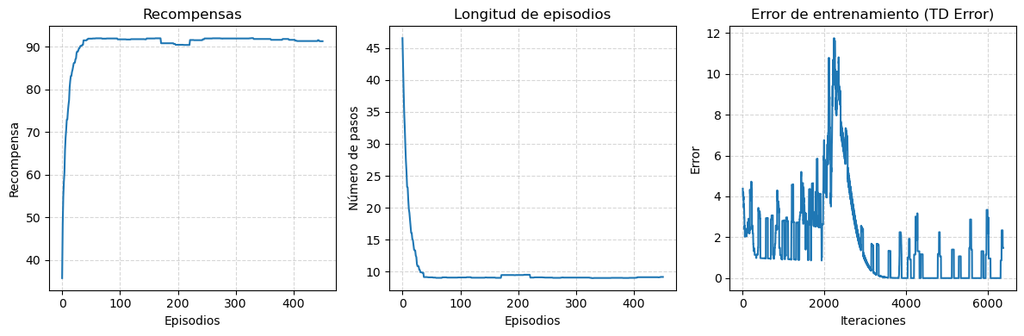

```python
# =========================
# NO MODIFICAR ESTA CELDA
# =========================
graficar_resultados(rewards_history, length_history, agent, CONFIG)
```

**c)**

**Funcionamiento del algoritmo Q-learning**

**Q-learning** es un algoritmo de aprendizaje por refuerzo basado en valores. Su objetivo es que el agente aprenda qué acción conviene tomar en cada estado para maximizar la recompensa acumulada.

Para ello, el agente prueba acciones dentro del entorno, recibe recompensas y actualiza progresivamente una tabla de valores llamada **q_table**. Esta actualización se basa en la recompensa inmediata obtenida y en la mejor recompensa futura estimada desde el siguiente estado. De esta forma, el agente va aprendiendo qué movimientos son más convenientes para llegar a la meta.

**¿Qué representa q_table?**

La **q_table** representa la memoria del agente. En este ejercicio, cada estado suele corresponder a una posición del agente dentro del laberinto, y para cada estado se guarda un valor asociado a cada acción posible.

El valor más alto indica la acción que, según lo aprendido hasta ese momento, tiene más probabilidad de conducir a una mejor recompensa futura.

**¿Qué pasa si el estado no existe en q_table?**

Si el agente llega a un estado que todavía no existe en **q_table**, se crea una nueva entrada para ese estado.

Normalmente, esta entrada se inicializa con un vector de ceros, por ejemplo mediante **np.zeros(len(self.actions))**. Así, el agente puede empezar a registrar información sobre ese nuevo estado a partir de las siguientes interacciones con el entorno.

**¿Por qué se inicializa con ceros?**

Se inicializa con ceros porque al principio el agente no tiene conocimiento previo sobre el laberinto. No sabe qué acciones son buenas, malas o inútiles.

El cero actúa como un valor inicial neutro. Después, a medida que el agente recibe recompensas positivas, penalizaciones o castigos por movimientos inválidos, esos valores se van ajustando.

**¿Qué significa random.random() < epsilon?**

La expresión **random.random() < epsilon** forma parte de la estrategia **epsilon-greedy**.

Si el número aleatorio generado es menor que **epsilon**, el agente explora y elige una acción al azar. Si no lo es, utiliza lo aprendido y selecciona la mejor acción conocida en la **q_table**.

Al principio, un valor alto de **epsilon** favorece la exploración. Más adelante, cuando **epsilon** disminuye, el agente empieza a explotar con más frecuencia la información aprendida.

**¿Qué significan las épocas en este ejercicio?**

Durante cada época, el agente interactúa con el laberinto, prueba acciones y actualiza la **q_table** según las recompensas obtenidas. Por tanto, cada episodio aporta experiencia nueva al aprendizaje del modelo.

**¿En qué época sería correcto terminar el aprendizaje de este modelo?**

Según las gráficas de recompensa y longitud de episodios, el aprendizaje podría detenerse cuando los resultados se estabilizan.

En este caso, la convergencia parece producirse aproximadamente entre las épocas **50 y 100**, ya que la recompensa se mantiene cerca de **92** y la longitud de los episodios se estabiliza en **9 pasos**.

A partir de ese punto, seguir entrenando no aporta una mejora significativa, porque el agente ya ha encontrado una política óptima o muy cercana a la óptima.

**¿Puedes graficar cuáles serían las dos mejores políticas para llegar al objetivo?**

Sí. Las dos mejores políticas corresponden a rutas de **9 movimientos**, que permiten llegar a la meta con una recompensa final de **92**:

**8 × (-1) + 100 = 92**

Esto significa que el agente realiza ocho pasos con penalización leve y en el noveno alcanza la recompensa positiva de la meta.

**Política 1:**

**ABAJO → ABAJO → DERECHA → DERECHA → DERECHA → DERECHA → ABAJO → DERECHA → DERECHA**

**Política 2:**

**ABAJO → ABAJO → DERECHA → DERECHA → DERECHA → DERECHA → DERECHA → ABAJO → DERECHA**

Ambas políticas son válidas porque alcanzan el objetivo en el mismo número de pasos. La diferencia está en el orden de los últimos movimientos, pero el rendimiento final es equivalente.

```
Política 1: ABAJO → ABAJO → DERECHA → DERECHA → DERECHA → DERECHA → ABAJO → DERECHA → DERECHA
Política 2: ABAJO → ABAJO → DERECHA → DERECHA → DERECHA → DERECHA → DERECHA → ABAJO → DERECHA
```

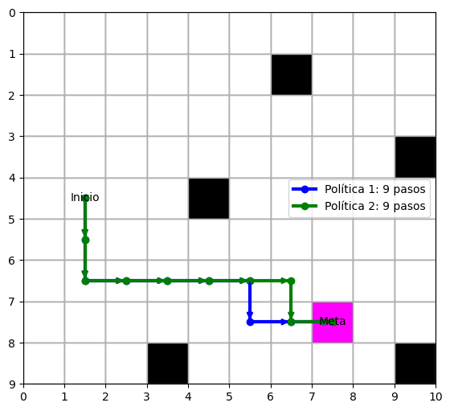

```python
from collections import deque
import matplotlib.patches as patches
import matplotlib.pyplot as plt # Añadido implícitamente por el uso de plt

def obtener_dos_mejores_rutas(laberinto, inicio, fin, k=2):
    cola = deque([(inicio, [inicio], [])])
    rutas = []

    # El bucle se ejecuta hasta vaciar la cola o encontrar 'k' rutas óptimas.
    while cola and len(rutas) < k:
        # Se extrae el nodo más antiguo (exploración en anchura).
        estado, camino, acciones = cola.popleft()

        # Condición de éxito por si se alcanza la meta, se guarda la trayectoria.
        if estado == fin:
            rutas.append((camino, acciones))
            continue

        # Expansión de nodos vecinos iterando sobre el espacio de acciones posible.
        for accion, (nombre, (df, dc)) in ACTIONS.items():
            nf = estado[0] + df
            nc = estado[1] + dc
            nuevo_estado = (nf, nc)

            # Control de ciclos para evitar que la ruta pase dos veces por la misma coordenada.
            if nuevo_estado in camino:
                continue

            # Validación de restricciones geométricas y de entorno (límites y obstáculos).
            if es_valido(laberinto, nf, nc):
                # Se encola el nuevo nodo añadiendo el estado y la acción al historial del camino.
                cola.append((
                    nuevo_estado,
                    camino + [nuevo_estado],
                    acciones + [nombre]
                ))

    return rutas


def graficar_rutas(laberinto, rutas, inicio, fin):
    filas, cols = len(laberinto), len(laberinto[0])
    fig, ax = plt.subplots(figsize=(8, 6))

    # Renderizado estático del entorno
    for r in range(filas):
        for c in range(cols):
            color = "white"
            if laberinto[r][c] == "X":
                color = "black"  # Obstáculos
            elif laberinto[r][c] == "O":
                color = "magenta" # Meta

            # Se dibuja la cuadrícula utilizando parches rectangulares.
            rect = patches.Rectangle((c, r), 1, 1, facecolor=color, edgecolor="gray")
            ax.add_patch(rect)

    colores = ["blue", "green"]

    # Renderizado dinámico de las trayectorias
    for i, (camino, acciones) in enumerate(rutas):
        # Se suma 0.5 para alinear los nodos en el centro geométrico de cada celda.
        xs = [c + 0.5 for r, c in camino]
        ys = [r + 0.5 for r, c in camino]

        # Trazo continuo de la ruta.
        ax.plot(xs, ys, marker="o", linewidth=3, color=colores[i],
                label=f"Política {i + 1}: {len(acciones)} pasos")

        # Inserción de vectores de dirección (flechas) entre nodos adyacentes.
        for j in range(len(camino) - 1):
            r1, c1 = camino[j]
            r2, c2 = camino[j + 1]
            ax.annotate(
                "",
                xy=(c2 + 0.5, r2 + 0.5),      # Coordenada destino de la flecha
                xytext=(c1 + 0.5, r1 + 0.5),  # Coordenada origen de la flecha
                arrowprops=dict(arrowstyle="->", color=colores[i], lw=2)
            )

        # Salida por consola de la secuencia de acciones evaluada.
        print(f"Política {i + 1}: {' → '.join(acciones)}")

    # Etiquetas y configuración de la vista del plano
    ax.text(inicio[1] + 0.5, inicio[0] + 0.5, "Inicio", ha="center", va="center")
    ax.text(fin[1] + 0.5, fin[0] + 0.5, "Meta", ha="center", va="center")

    ax.set_xlim(0, cols)
    ax.set_ylim(filas, 0) # Inversión del eje Y para coincidir con la matriz (fila 0 arriba).
    ax.set_aspect("equal") # Mantiene la proporción cuadrada de las celdas.
    ax.set_xticks(range(cols + 1))
    ax.set_yticks(range(filas + 1))
    ax.grid(True)
    ax.legend()

    plt.show()

# Main
rutas = obtener_dos_mejores_rutas(laberinto, inicio, fin)
graficar_rutas(laberinto, rutas, inicio, fin)
```

**d) Análisis de diferentes parámetros de aprendizaje[1 pt.]**

Desarrolla la lógica necesaria para ejecutar el entrenamiento del agente utilizando las diferentes configuraciones A, B y C. Para cada configuración, genera las gráficas correspondientes y realiza un análisis comparativo de los resultados obtenidos.

A partir de dichas gráficas, describe la evolución de las recompensas, la longitud de los episodios y el error de entrenamiento. Explica qué indican estas métricas sobre el proceso de aprendizaje del agente.

Analiza específicamente cómo influyen los parámetros learning rate, gamma, epsilon y epsilon decay en el comportamiento observado.

```python
# =========================
# NO MODIFICAR ESTA CELDA
# =========================

# =========================
# CONFIGURACIÓN EXPERIMENTAL - A
# =========================
CONFIG_A = {
    "episodes": 500,
    "learning_rate": 0.01,
    "gamma": 0.1,
    "epsilon": 0.01,
    "epsilon_decay": 0.999,
    "rolling_window": 50
}
# =========================
# CONFIGURACIÓN EXPERIMENTAL - B
# =========================
CONFIG_B = {
    "episodes": 500,
    "learning_rate": 0.01,
    "gamma": 0.90,
    "epsilon": 1.0,
    "epsilon_decay": 0.995,
    "rolling_window": 50
}
# =========================
# CONFIGURACIÓN EXPERIMENTAL - C
# =========================
CONFIG_C = {
    "episodes": 500,
    "learning_rate": 0.2,
    "gamma": 0.80,
    "epsilon": 1.0,
    "epsilon_decay": 0.97,
    "rolling_window": 50
}
```

[output not shown]

[output cut: 59131 more lines]

```
Acción seleccionada: IZQUIERDA
Acción seleccionada: ABAJO
Acción seleccionada: DERECHA
Acción seleccionada: IZQUIERDA
Acción seleccionada: ARRIBA
Acción seleccionada: DERECHA
Acción seleccionada: DERECHA
Acción seleccionada: DERECHA
Acción seleccionada: DERECHA
Acción seleccionada: DERECHA
Acción seleccionada: ABAJO
Acción seleccionada: DERECHA
Episodio 500 | Recompensa: 38.0 | Epsilon: 0.010

🎯 Entrenamiento terminado
```

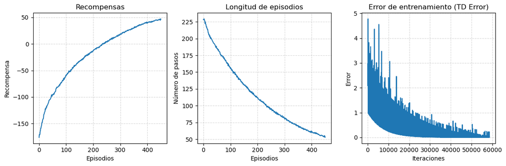

```python
# =========================
# IMPLEMENTA EL CÓDIGO PARA PROBAR CADA CONFIGURACIÓN
# =========================
# CONFIGURACIÓN EXPERIMENTAL - A

# 1. Crear entorno y agente con CONFIG_A
env_A = DogMazeEnv(laberinto, inicio, fin)
agent_A = QAgent(ACTIONS, CONFIG_A)

# 2. Entrenar agente
print("Iniciando entrenamiento con CONFIG_A...")
rewards_history_A, length_history_A = entrenar_agente(env_A, agent_A, CONFIG_A)

# 3. Graficar resultados
graficar_resultados(rewards_history_A, length_history_A, agent_A, CONFIG_A)
```

[output not shown]

[output cut: 19800 more lines]

```
Acción seleccionada: DERECHA
Acción seleccionada: ABAJO
Episodio 499 | Recompensa: 92.0 | Epsilon: 0.010
Acción seleccionada: ABAJO
Acción seleccionada: DERECHA
Acción seleccionada: ABAJO
Acción seleccionada: DERECHA
Acción seleccionada: DERECHA
Acción seleccionada: DERECHA
Acción seleccionada: DERECHA
Acción seleccionada: DERECHA
Acción seleccionada: ABAJO
Episodio 500 | Recompensa: 92.0 | Epsilon: 0.010

🎯 Entrenamiento terminado
```

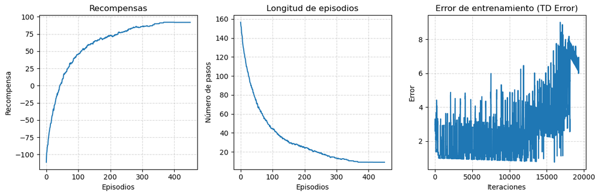

```python
# CONFIGURACIÓN EXPERIMENTAL - B

# 1. Crear entorno y agente con CONFIG_B
env_B = DogMazeEnv(laberinto, inicio, fin)
agent_B = QAgent(ACTIONS, CONFIG_B)

# 2. Entrenar agente
print("Iniciando entrenamiento con CONFIG_B...")
rewards_history_B, length_history_B = entrenar_agente(env_B, agent_B, CONFIG_B)

# 3. Graficar resultados
graficar_resultados(rewards_history_B, length_history_B, agent_B, CONFIG_B)
```

[output not shown]

[output cut: 6213 more lines]

```
Acción seleccionada: ABAJO
Acción seleccionada: DERECHA
Episodio 499 | Recompensa: 92.0 | Epsilon: 0.010
Acción seleccionada: DERECHA
Acción seleccionada: ABAJO
Acción seleccionada: ABAJO
Acción seleccionada: DERECHA
Acción seleccionada: DERECHA
Acción seleccionada: DERECHA
Acción seleccionada: DERECHA
Acción seleccionada: ABAJO
Acción seleccionada: DERECHA
Episodio 500 | Recompensa: 92.0 | Epsilon: 0.010

🎯 Entrenamiento terminado
```

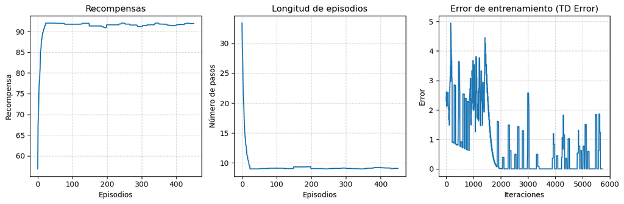

```python
# CONFIGURACIÓN EXPERIMENTAL - C

# 1. Crear entorno y agente con CONFIG_C
env_C = DogMazeEnv(laberinto, inicio, fin)
agent_C = QAgent(ACTIONS, CONFIG_C)

# 2. Entrenar agente
print("Iniciando entrenamiento con CONFIG_C...")
rewards_history_C, length_history_C = entrenar_agente(env_C, agent_C, CONFIG_C)

# 3. Graficar resultados
graficar_resultados(rewards_history_C, length_history_C, agent_C, CONFIG_C)
```

**d)**

**Análisis comparativo de las configuraciones A, B y C**

Para comparar las configuraciones **A, B y C**, se entrena el agente varias veces modificando los hiperparámetros principales del algoritmo: **learning_rate**, **gamma**, **epsilon** y **epsilon_decay**. En cada entrenamiento se registran tres métricas: la recompensa obtenida por episodio, la longitud de cada episodio y el error de actualización de la **Q-table**.

En todos los casos se mantiene el mismo número de episodios de entrenamiento, 500, porque es el valor definido en las configuraciones experimentales. Esto permite comparar las tres configuraciones en igualdad de condiciones y observar cómo evolucionan las métricas bajo distintos valores de **learning_rate**, **gamma**, **epsilon** y **epsilon_decay**.

Estas gráficas permiten observar si el agente aprende una política útil, si reduce progresivamente el número de pasos necesarios para llegar a la meta y si las actualizaciones de la tabla Q se van estabilizando.

**Configuración A**

En la **Configuración A** el agente sí muestra cierta mejora, pero el aprendizaje es muy lento y no alcanza la política óptima. Las recompensas pasan de valores muy negativos a valores positivos moderados, y la longitud de los episodios disminuye, lo que indica que el agente aprende algunos caminos mejores.

Sin embargo, no llega a estabilizarse cerca de la recompensa máxima de 92 ni de los 9 pasos óptimos. Esto se debe principalmente al bajo epsilon inicial, que limita la exploración, y al **gamma = 0.1**, que reduce mucho la importancia de la recompensa futura de la meta.

**Configuración B**

También existe una exploración suficiente al comienzo, lo que ayuda a encontrar caminos posibles. Sin embargo, el **learning_rate = 0.01** hace que las actualizaciones de la **Q-table** sean muy pequeñas. Por eso, la recompensa aumenta de forma gradual y la longitud de los episodios tarda más en reducirse.

En las gráficas, esta configuración refleja una mejora progresiva, pero menos rápida que en la configuración C.

**Configuración C**

La **Configuración C** suele ofrecer el aprendizaje más rápido en este laberinto. Su **learning_rate** alto permite modificar con más fuerza los valores Q tras cada experiencia, por lo que el agente incorpora antes la información obtenida.

Además, el **epsilon_decay = 0.97** reduce la exploración con bastante rapidez. Esto hace que el agente pase pronto de probar acciones aleatorias a explotar la mejor ruta encontrada. Como resultado, las recompensas tienden a subir antes y la longitud de los episodios disminuye con mayor rapidez.

Sin embargo, esta configuración también puede ser más sensible a decisiones tempranas. Si el agente encuentra una ruta aceptable pero no óptima al principio, podría dejar de explorar demasiado pronto.

**Evolución de las métricas**

La **recompensa por episodio** indica la calidad del comportamiento del agente. Si aumenta con el entrenamiento, significa que el agente está aprendiendo acciones más adecuadas para acercarse a la meta.

La **longitud de los episodios** muestra cuántos pasos necesita el agente para completar el recorrido. Una disminución progresiva indica que el agente está encontrando rutas más directas y eficientes.

El **error de entrenamiento** refleja cuánto cambian los valores de la **Q-table** en cada actualización. Al principio suele ser mayor, porque el agente todavía está aprendiendo. Cuando el error se reduce y se estabiliza, significa que la tabla Q está convergiendo y que el aprendizaje empieza a consolidarse.

**Influencia de los hiperparámetros**

El **learning_rate** controla cuánto cambia la **Q-table** en cada actualización. Un valor bajo produce un aprendizaje más lento pero estable, mientras que un valor alto acelera el aprendizaje, aunque puede generar más inestabilidad.

El parámetro **gamma** determina la importancia de las recompensas futuras. Si es muy bajo, el agente se centra demasiado en recompensas inmediatas y le cuesta valorar una meta lejana. Si es alto, puede planificar mejor a largo plazo.

El valor **epsilon** controla la exploración. Cuando es alto, el agente prueba más acciones aleatorias. Cuando es bajo, utiliza con más frecuencia lo que ya ha aprendido.

Por último, **epsilon_decay** define la velocidad con la que disminuye la exploración. Si baja demasiado rápido, el agente puede dejar de explorar antes de encontrar la mejor ruta. Si baja muy lento, puede tardar más en aprovechar la política aprendida.

**Conclusiones finales**

Comparando las tres configuraciones, la **A** es la menos efectiva porque limita la exploración inicial y valora poco las recompensas futuras. La **B** aprende de forma más segura, pero necesita más episodios para mejorar. La **C** obtiene los mejores resultados en menos tiempo, ya que combina actualizaciones fuertes con una reducción rápida de la exploración.

Por lo tanto, para este laberinto, la **Configuración C** parece ser la más eficiente, aunque conviene vigilar que no deje de explorar demasiado pronto.

# Ejercicio 3 - Diseño de sistemas multiagente

**Ejercicio 3 [1 pts.]**

Plantea una solución al problema del cachorro en el laberinto utilizando un sistema multiagente. Define los agentes involucrados, sus funciones y cómo se comunican y coordinan entre sí. Finalmente, explica qué ventajas tendría este enfoque frente a un agente único. Representa gráficamente tu diseño (por ejemplo, mediante un esquema o diagrama) y explica su funcionamiento.

**a)**

**Sistema multiagente para resolver el problema del cachorro en el laberinto**

Para resolver el problema del cachorro en el laberinto mediante un **sistema multiagente**, se puede dividir la tarea en varios agentes especializados. En lugar de que un único agente explore, aprenda y corrija sus errores mediante prueba y error, cada agente asume una función concreta dentro del sistema.

**1. Agentes involucrados y funciones**

**Agentes exploradores**

Los agentes exploradores son agentes virtuales pequeños, de tamaño **1x1**, que recorren el laberinto para identificar casillas libres, obstáculos y posibles caminos hacia la meta.

Su función principal es recopilar información del entorno. Aunque pueden moverse con más facilidad que el cachorro, sus resultados deben validarse después teniendo en cuenta el tamaño completo del agente principal.

**Agente planificador**

El agente planificador actúa como coordinador. No se mueve físicamente por el laberinto, sino que recibe la información recogida por los exploradores y calcula una ruta segura.

Para ello, puede utilizar algoritmos de búsqueda como **A***, **BFS** o **Dijkstra**. La clave es que no valida solo una casilla, sino todas las casillas ocupadas por el cachorro mediante su forma completa, por ejemplo usando **DOG_SHAPE**.

**Agente ejecutor**

El agente ejecutor representa al cachorro. Es el agente que realmente se desplaza por el laberinto y ocupa varias casillas al mismo tiempo.

Su función es seguir la ruta calculada por el planificador, evitando movimientos inválidos y reduciendo las colisiones con obstáculos.

**2. Comunicación y coordinación**

La comunicación entre agentes se organiza mediante una **pizarra compartida**. Esta pizarra actúa como una memoria común donde se almacena el mapa conocido del laberinto.

Los agentes exploradores escriben en ella la información que descubren: casillas libres, obstáculos y zonas exploradas. Después, el agente planificador consulta esa información para calcular una ruta válida. Finalmente, el agente ejecutor recibe la secuencia de movimientos seguros y la aplica en el entorno.

**3. Representación gráfica del sistema**

[figure not shown]

**4. Funcionamiento del sistema**

En la primera fase, los agentes exploradores recorren el laberinto y registran la información básica del entorno en la pizarra compartida.

En la segunda fase, el agente planificador analiza el mapa construido y calcula una ruta posible hasta la meta. En este paso se comprueba que el cachorro completo pueda pasar, no solo su posición central.

En la tercera fase, el agente ejecutor recibe la secuencia de movimientos y avanza por el laberinto siguiendo una ruta segura. Así se reducen los choques y se evita que el cachorro tenga que aprender únicamente mediante errores repetidos.

**5. Ventajas frente a un agente único**

Este enfoque mejora la exploración, ya que varios agentes pueden analizar distintas zonas del mapa al mismo tiempo. Esto permite obtener información útil más rápido que con un único agente.

También reduce las colisiones del cachorro. En un sistema basado solo en Q-learning, el agente suele aprender chocando muchas veces contra obstáculos. En cambio, con un sistema multiagente, el recorrido puede planificarse antes de ejecutar el movimiento.

Además, el diseño es más modular. Si cambia la forma del cachorro, solo habría que modificar la validación del agente planificador, mientras que los exploradores podrían seguir funcionando igual.

En resumen, el sistema multiagente separa la exploración, la planificación y la ejecución. Esto permite una solución más eficiente, más clara y menos dependiente del aprendizaje por prueba y error de un único agente.

# Bibliografía

Dijkstra, E. W. (1959). A note on two problems in connexion with graphs. Numerische Mathematik, 1, 269-271. https://doi.org/10.1007/BF01386390

Farama Foundation. (s. f.). Gymnasium [Software]. https://gymnasium.farama.org/

Hart, P. E., Nilsson, N. J., y Raphael, B. (1968). A formal basis for the heuristic determination of minimum cost paths. IEEE Transactions on Systems Science and Cybernetics, 4(2), 100-107. https://doi.org/10.1109/TSSC.1968.300136

Hunter, J. D. (2007). Matplotlib: A 2D graphics environment. Computing in Science & Engineering, 9(3), 90-95. https://doi.org/10.1109/MCSE.2007.55

Moreno i Ribas, A. (s. f.). Agentes y sistemas multiagente (módulo 2). Fundació Universitat Oberta de Catalunya.

Moreno i Ribas, A., Torra i Reventós, V., y Masip i Rodó, D. (2013). Aprendizaje computacional (módulo 0). Fundació Universitat Oberta de Catalunya.

Nii, H. P. (1994). Blackboard systems at the architecture level. Expert Systems with Applications, 7(1), 43-54. https://doi.org/10.1016/0957-4174(94)90025-6

NumPy Developers. (s. f.). NumPy [Software]. https://numpy.org/

OpenAI. (2026). ChatGPT (modelo GPT-5.5) [Modelo de lenguaje grande]. https://chatgpt.com/

Project Jupyter. (s. f.). Jupyter Notebook [Software]. https://jupyter.org/

Python Software Foundation. (s. f.). Python language reference [Software]. https://www.python.org/

Sutton, R. S., y Barto, A. G. (2018). Reinforcement learning: An introduction (2.ª ed.). MIT Press. http://incompleteideas.net/book/the-book-2nd.html

Torra i Reventós, V., y Masip i Rodó, D. (s. f.). Aprendizaje (módulo 1). Fundació Universitat Oberta de Catalunya.

Watkins, C. J. C. H., y Dayan, P. (1992). Q-learning. Machine Learning, 8, 279-292. https://doi.org/10.1007/BF00992698

Wooldridge, M. J. (2009). An introduction to multiagent systems (2.ª ed.). John Wiley & Sons.

# Citación de la IA generativa utilizada

Durante la elaboración de esta PEC se ha hecho uso de la herramienta ChatGPT (versión GPT-5.5) desarrollada por OpenAI, como apoyo en la redacción y revisión de algunos apartados teóricos.

Se ha supervisado y editado todo el contenido de forma exhaustiva, garantizando que el resultado final sea original, riguroso y coherente con los criterios académicos de la UOC.